# Replicate SPIROMICS eQTLs in GTEx v8

Silva Kasela

06/01/2020

## Data

#### SPIROMICS eQTLs

- No. of significant eGenes in SPIROMICS at FDR 5% - **4881** eGenes

#### eQTLs from GTEx v8

- eQTLs for 49 tissues from GTEx v8

How many gene-variant pairs from SPIROMCS are present in different GTEx tissues? - On average 3962.6530612 gene-variant pairs

How many gene-variant pairs from SPIROMCS are present in different GTEx tissues, but have nominal p-value >= 0.05 ? - On average 1808.8367347 gene-variant pairs

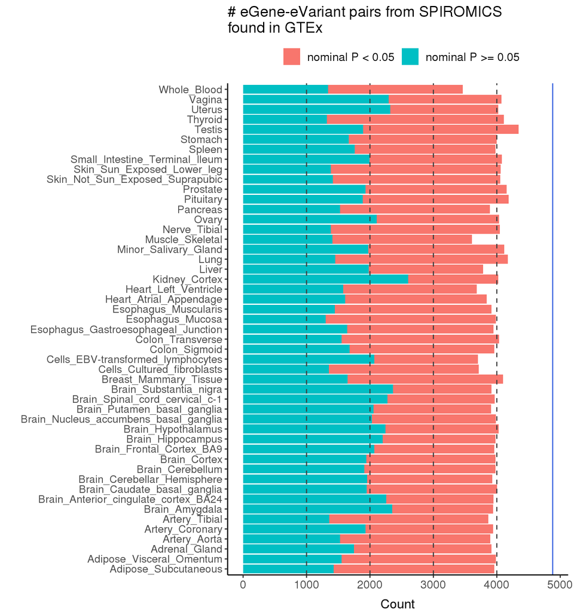

**Bronchial epithelium eQTLs that have not been discovered before from GTEx v8**

- 165 (3.4%) eGenes (not gene-variant pairs) not found from any of the GTEx tissues
  - Not expressed or no data?
- 492 (10.08%) eGenes (not gene-variant pairs) not found from Lung
- 318 (6.515%) eGenes (not gene-variant pairs) not found from any of the GTEx tissues or the gene-variant pair has nominal p-value > 0.05 in all the tissues

**Bronchial epithelium eQTLs that have not been discovered before from the eQTLGen Consortium**

- 1395 (28.6%) eGenes (not gene-variant pairs) not found from eQTLGen Consortium
  - Not expressed or issues with gene annotations?
- 1395 (28.58%) eGenes (not gene-variant pairs) not found from eQTLGen Consortium or have minimum nominal p-value >= 0.05

```
##                       Not discovered in eQTLGen
## Not discovered in GTEx FALSE TRUE
##                  FALSE  3464 1252
##                  TRUE     22  143
```

## Replication of SPIROMICS eQTLs in GTEx

Calculate pi1, and compare the p-values and slopes of gene-variants pairs in SPIROMICS and GTEx

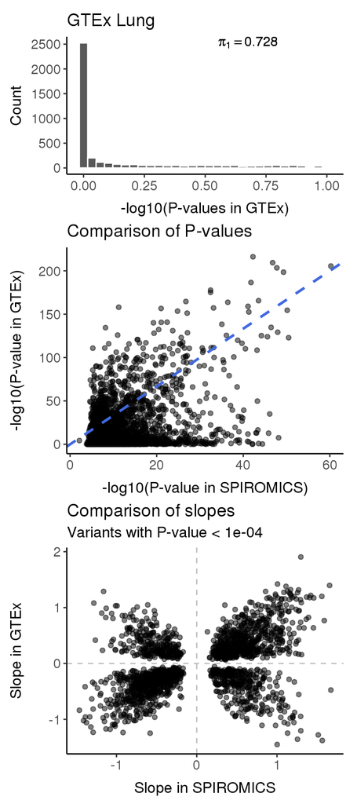

Two different metrics for estimating replication rate:

- concordance rate - proportion of gene-variant pairs that have the same direction of effect
  - Only for gene-variant pairs that have nominal p-value < 10^{-4} in GTEx
- $\pi_1$, proportion of true positives

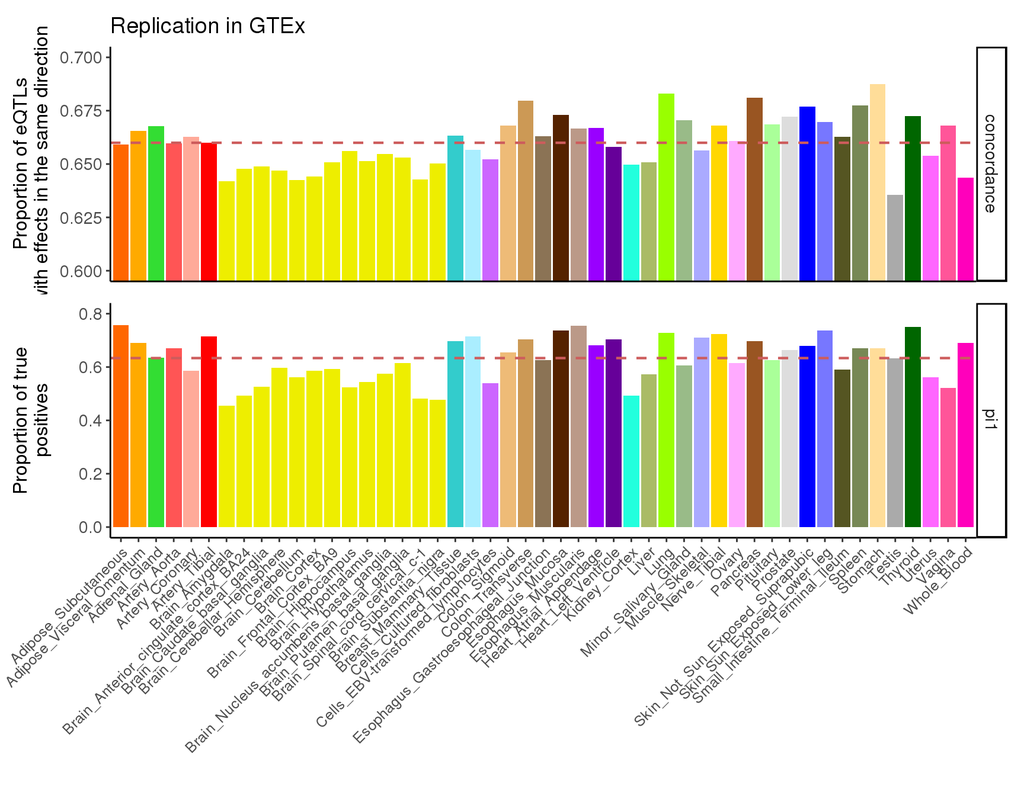

Note: red lines denotes the median of the given replication metrics.

#### Replication estimates and cell type enrichment

Using the xCell enrichment scores for 7 cell types across all tissue samples to explain the replication patterns:

- adipocytes, epithelial cells, hepatocytes, keratinocytes, myocytes, neurons, neutrophils

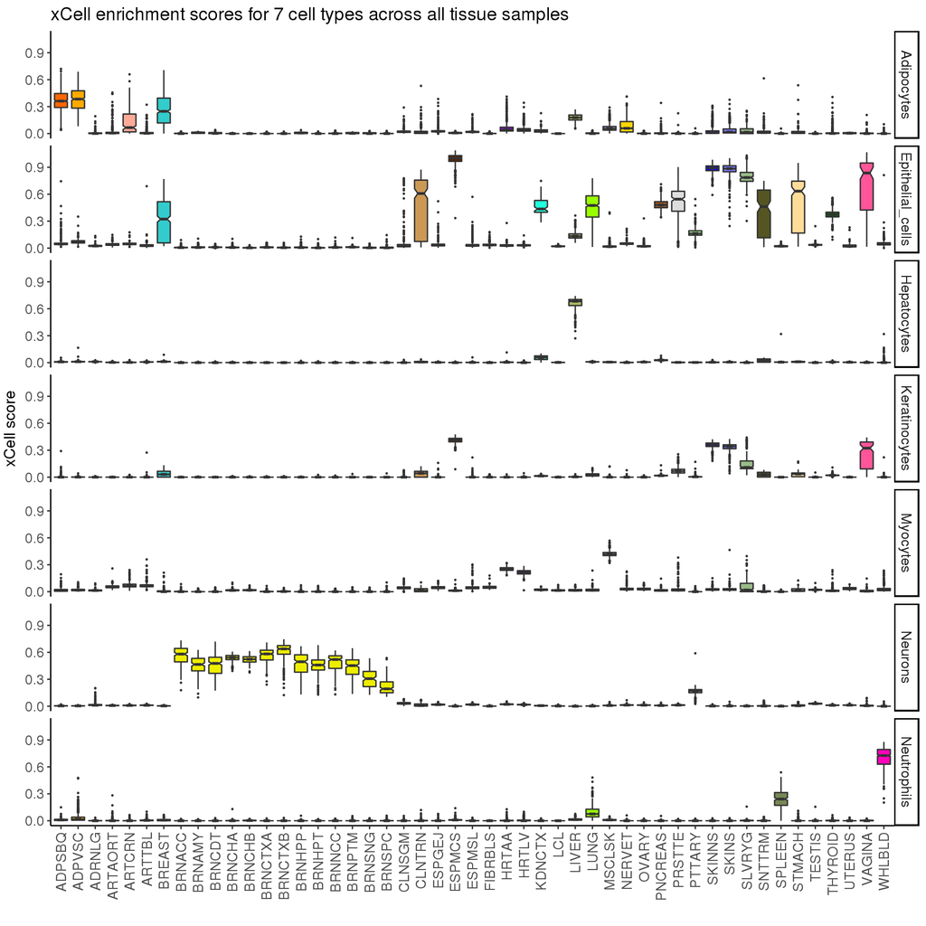

Plotting median xCell enrichemnt score against replication estimate

- Is there statistically significant differences between tissues with high enrichment score for a particular cell type?
  - Wilcoxon rank sum test between tissues with median enrichment score > 0.1 (enriched tissues) VS others (not enriched for this given cell type)

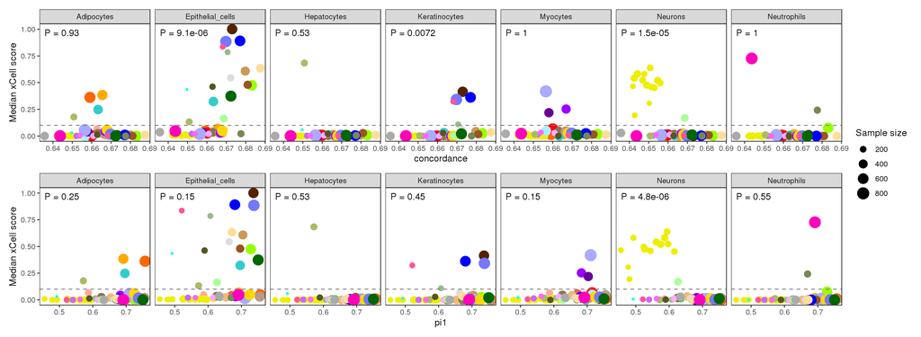

Tissues with the median epithelial cell enrichment score > 0.1 - 16 tissues:

| tissue_id | cell_type | n | xcell_median | xcell_mean | enriched_tissue | pi1 | concordance |
| --- | --- | --- | --- | --- | --- | --- | --- |
| Esophagus_Mucosa | Epithelial_cells | 555 | 1.00080 | 0.9869897 | 1 | 0.7360884 | 0.6730000 |
| Skin_Not_Sun_Exposed_Suprapubic | Epithelial_cells | 604 | 0.89125 | 0.8847300 | 1 | 0.6802948 | 0.6770567 |
| Skin_Sun_Exposed_Lower_leg | Epithelial_cells | 701 | 0.88500 | 0.8715298 | 1 | 0.7373217 | 0.6697743 |
| Vagina | Epithelial_cells | 156 | 0.83570 | 0.6568385 | 1 | 0.5211115 | 0.6681514 |
| Minor_Salivary_Gland | Epithelial_cells | 162 | 0.78560 | 0.8011265 | 1 | 0.6069323 | 0.6706383 |
| Stomach | Epithelial_cells | 359 | 0.63380 | 0.5130705 | 1 | 0.6715550 | 0.6875776 |
| Colon_Transverse | Epithelial_cells | 406 | 0.60800 | 0.4570845 | 1 | 0.7043626 | 0.6797753 |
| Prostate | Epithelial_cells | 245 | 0.54460 | 0.5006473 | 1 | 0.6633055 | 0.6722338 |
| Pancreas | Epithelial_cells | 328 | 0.47970 | 0.4864216 | 1 | 0.6962463 | 0.6810237 |
| Lung | Epithelial_cells | 578 | 0.47475 | 0.4540133 | 1 | 0.7279955 | 0.6831633 |
| Small_Intestine_Terminal_Ileum | Epithelial_cells | 187 | 0.46200 | 0.3999107 | 1 | 0.5894832 | 0.6628664 |
| Kidney_Cortex | Epithelial_cells | 85 | 0.43560 | 0.4627082 | 1 | 0.4922079 | 0.6496350 |
| Thyroid | Epithelial_cells | 653 | 0.37370 | 0.3748462 | 1 | 0.7501809 | 0.6723581 |
| Breast_Mammary_Tissue | Epithelial_cells | 459 | 0.32290 | 0.3088381 | 1 | 0.6961926 | 0.6633017 |
| Pituitary | Epithelial_cells | 283 | 0.16350 | 0.1713304 | 1 | 0.6266852 | 0.6686352 |
| Liver | Epithelial_cells | 226 | 0.13255 | 0.1423310 | 1 | 0.5716860 | 0.6508088 |

How much sample size affects the replication estimates?

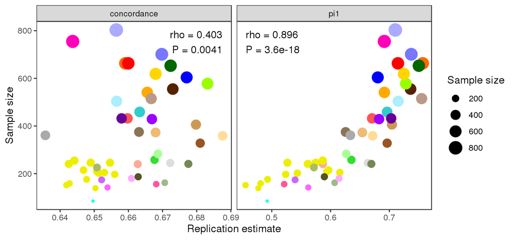

Combine into one figure showing the effect of sample size and epithelial cell enrichment on replication measures.

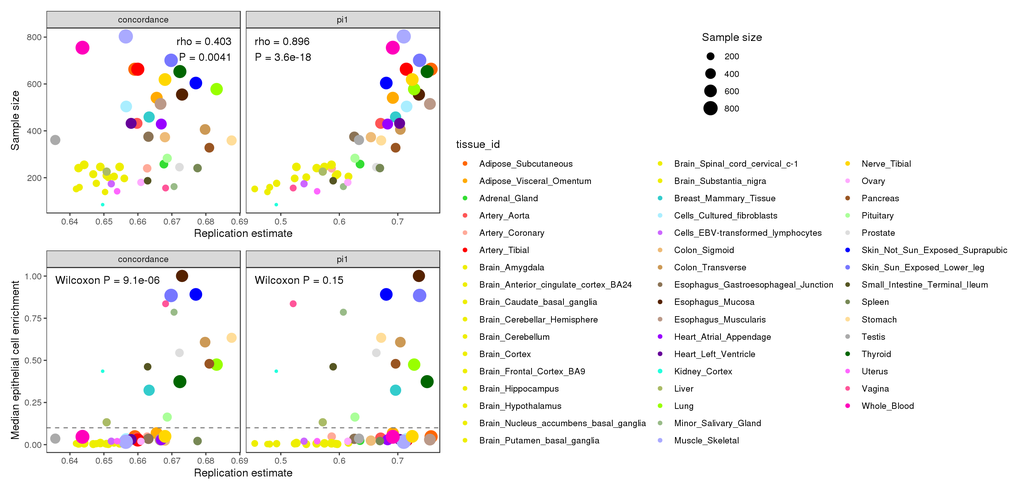